# Simulating Correlated Data

Jay Lee

4/12/2018

## Big Question

Can we simulate arbitrary correlated data? That is, in addition to simulating multiple correlated normal random variables, can we simulate for other distributions?

## First Question

How does `rvnorm` actually work? How do we simulate correlated multivariate normal data? Say we want to simulate some random vector (a vector of random variables) $Y$ of length $n$ such that
$$Y \sim \mathcal{N}\left( \mu, \Sigma\right).$$
Then, let $Z \sim \mathcal{N}\left( 0, I_n \right)$. If we find some $C$ such that $\Sigma = CC'$, then, $Y = \mu + CZ$. That is, if we can simulate uncorrelated normal random variables, we can simulate correlated normal random variables. We can verify that this construction for $Y$ has the properties we want: ——– a. Expectation.
$$E(Y) = E(\mu + CZ) = E(\mu) + E(C)E(Z) = \mu.$$
(Notes: $\mu$ is a constant, $C$ and $Z$ are independent, and $E(Z) = 0$.) b. Variance.
$$V(Y) = V(\mu + CZ) = V(\mu) + C \cdot V(Z) \cdot C' = CC' = \Sigma.$$
c. Multivariate normally distributed. By definition, a random vector is multivariate normally distributed if any linear combination of its components is normally distributed. Since $Z$ is multivariate normally distributed and $C$ is a constant matrix, $CZ$ is a vector of linear combinations of the components of $Z$, and $C$ is multivariate normally distributed. Since $Y = \mu + CZ$ and $\mu$ is a constant vector, $Y \sim \mathcal{N}\left( \mu, \Sigma\right)$.

## Methods for finding $C$

- Eigenvalue decomposition
- Singular value decomposition
- Cholesky decomposition (fastest, by a little) ## Simulating correlated variables: the inverse CDF

```r
mu <- c(5,4,3,2,1)
Sigma <- matrix(c(1 ,.8,.6,.4,.2,
                  .8, 2,.8,.6,.4,
                  .6,.8, 3,.8,.6,
                  .4,.6,.8, 4,.8,
                  .2,.4,.6,.8, 5), ncol = 5)
rawvars <- data.frame(mvrnorm(10000, mu, Sigma, empirical = TRUE))
cor(rawvars)
```

```
##            X1        X2        X3        X4         X5
## X1 1.00000000 0.5656854 0.3464102 0.2000000 0.08944272
## X2 0.56568542 1.0000000 0.3265986 0.2121320 0.12649111
## X3 0.34641016 0.3265986 1.0000000 0.2309401 0.15491933
## X4 0.20000000 0.2121320 0.2309401 1.0000000 0.17888544
## X5 0.08944272 0.1264911 0.1549193 0.1788854 1.00000000
```

## Make correlated poisson variable

```r
# these are all normalized, they're probabilities
pvars <- data.frame(X1 = pnorm(rawvars$X1, mean = mu[1], sd = sqrt(Sigma[1,1])),
                    X2 = pnorm(rawvars$X2, mean = mu[2], sd = sqrt(Sigma[2,2])),
                    X3 = pnorm(rawvars$X3, mean = mu[3], sd = sqrt(Sigma[3,3])),
                    X4 = pnorm(rawvars$X4, mean = mu[4], sd = sqrt(Sigma[4,4])),
                    X5 = pnorm(rawvars$X5, mean = mu[5], sd = sqrt(Sigma[5,5])))
pvarmat <- data.matrix(pvars)
poisvars <- data.frame(qpois(pvarmat, 5))
(pois_error <- max(abs(zapsmall(cor(rawvars) - cor(poisvars), digits = 3))))
```

```
## [1] 0.01264
```

Repeated for binomial, exponential, and uniform.

```r
cor(rawvars)
```

```
##            X1        X2        X3        X4         X5
## X1 1.00000000 0.5656854 0.3464102 0.2000000 0.08944272
## X2 0.56568542 1.0000000 0.3265986 0.2121320 0.12649111
## X3 0.34641016 0.3265986 1.0000000 0.2309401 0.15491933
## X4 0.20000000 0.2121320 0.2309401 1.0000000 0.17888544
## X5 0.08944272 0.1264911 0.1549193 0.1788854 1.00000000
```

```r
c(pois_error, binom_error, exp_error, unif_error)
```

```
## [1] 1.264e-02 9.480e-02 5.170e-02 1.110e-16
```

Each of these has correlation matrix very similar to the correlation matrix of the original. In general you can’t transitively apply correlation, i.e. $X$ correlated to $Y$ and $Y$ correlated to $Z$ doesn’t give $X$ correlated to $Z$, so this isn’t accurate if you apply it more than once.

## Simulating correlated to known vector

```r
# our initial data
x1 <- runif(100, 5, 15)
```

[output not shown]

```r
newc <- matrix(c(1  , 0.8, 0.6, 0.4, #this is our desired correlation matrix
                 0.8, 1  , 0.8, 0.6,
                 0.6, 0.8, 1  , 0.8,
                 0.4, 0.6, 0.8, 1  ), ncol=4 )
eigen(newc)$values # check that it is positive definite
```

```
## [1] 3.0142136 0.6828427 0.1857864 0.1171573
```

[output not shown]

[output not shown]

[output not shown]

[output not shown]

[output not shown]

[output not shown]

```r
# verify success
mean(x1)
```

```
## [1] 9.785712
```

```r
colMeans(finalx)
```

```
## [1] 9.785712 9.785712 9.785712 9.785712
```

```r
sd(x1)
```

```
## [1] 2.791524
```

```r
apply(finalx, 2, sd)
```

```
## [1] 2.791524 2.791524 2.791524 2.791524
```

```r
cor(finalx)
```

```
##      [,1] [,2] [,3] [,4]
## [1,]  1.0  0.8  0.6  0.4
## [2,]  0.8  1.0  0.8  0.6
## [3,]  0.6  0.8  1.0  0.8
## [4,]  0.4  0.6  0.8  1.0
```

```r
all.equal(x1, finalx[,1])
```

```
## [1] TRUE
```

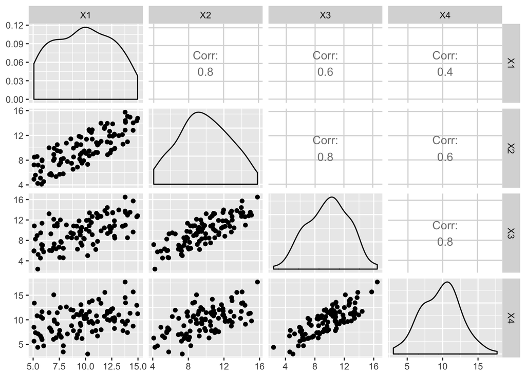

```r
ggpairs(data.frame(finalx))
```

## Pros and cons

First method * Adds some noise (shrinkage) in the correlation * Requires a normal distribution to initialize * Guarantees the (output) distributions you want in your correlated variables Second method * Maintains correlations much better * Allows any initial distribution (or vector) * Everything start to drift towards normality (Central Limit Theorem?)

## Sources

- [Motivation for `mvnorm`](https://math.stackexchange.com/questions/446093/generate-correlated-normal-random-variables)
- [Inverse CDF method](https://www.r-bloggers.com/easily-generate-correlated-variables-from-any-distribution-without-copulas/)
- [Method from given vector](https://stat.ethz.ch/pipermail/r-help/2007-April/128925.html)